# Aspects of Danceability

## Rachel Garcia

### Tuesday, April 28, 2026

# Outline

1. Background & Motivation
2. The Data
3. Exploratory Analysis
4. Methods
5. Results
6. Example
7. Conclusion and Reflection

# Background

In the aftermath of the pandemic, people are feeling mass amounts of disconnect. This mental impact has left people more willing to find community than ever. **Dance** is a way to connect people from any background.

# The Question

## *What audio features make a song danceable?*

### **Why this matters:** More danceable music = more dancing = stronger communities!

# The Formula

This analysis resulted in a few key findings for what can systematically create a danceble track.

1. High **valence** or 'feel-good' vibe throughout
2. High percentage of **speechiness** - indicating more rap, hip-hop, reggaeton, trap, etc.
3. Strong, consistent, driving rhythm

# The Dataset

- High popularity songs from Spotify's API, as sourced from Kaggle
- 1686 tracks, 29 columns
- Target variable: **Danceability** (0-1 scale)

# Summary Statistics

- Mean danceability is 0.65 -- songs are relatively danceable
- Max danceability is 0.979

```python
#Summary Statistics
Spotify_DF.describe()
```

|  | energy | tempo | danceability | loudness | liveness | valence | time_signature | speechiness | track_popularity | instrumentalness | mode | key | duration_ms | acousticness |
| --- | --- | --- | --- | --- | --- | --- | --- | --- | --- | --- | --- | --- | --- | --- |
| count | 1686.000000 | 1686.000000 | 1686.000000 | 1686.000000 | 1686.000000 | 1686.000000 | 1686.000000 | 1686.000000 | 1686.000000 | 1686.000000 | 1686.000000 | 1686.000000 | 1686.000000 | 1686.000000 |
| mean | 0.667216 | 121.070938 | 0.650362 | -6.704131 | 0.171579 | 0.525737 | 3.950178 | 0.100926 | 75.806050 | 0.041520 | 0.578292 | 5.338078 | 214562.125741 | 0.221220 |
| std | 0.184908 | 27.066029 | 0.157721 | 3.377068 | 0.123953 | 0.236113 | 0.326673 | 0.099748 | 6.032532 | 0.156556 | 0.493979 | 3.608208 | 58310.747929 | 0.250593 |
| min | 0.001610 | 49.305000 | 0.136000 | -43.643000 | 0.021000 | 0.034800 | 1.000000 | 0.023200 | 68.000000 | 0.000000 | 0.000000 | 0.000000 | 61673.000000 | 0.000013 |
| 25% | 0.551000 | 100.058750 | 0.543250 | -7.950250 | 0.093400 | 0.339000 | 4.000000 | 0.037900 | 71.000000 | 0.000000 | 0.000000 | 2.000000 | 176607.750000 | 0.023050 |
| 50% | 0.689000 | 120.001000 | 0.664500 | -5.974500 | 0.121000 | 0.528000 | 4.000000 | 0.058100 | 75.000000 | 0.000006 | 1.000000 | 5.000000 | 211180.000000 | 0.124000 |
| 75% | 0.807000 | 136.833500 | 0.769000 | -4.687250 | 0.210000 | 0.720000 | 4.000000 | 0.118000 | 79.000000 | 0.000814 | 1.000000 | 8.000000 | 244993.250000 | 0.334750 |
| max | 0.990000 | 209.688000 | 0.979000 | 1.295000 | 0.950000 | 0.978000 | 5.000000 | 0.848000 | 100.000000 | 0.971000 | 1.000000 | 11.000000 | 547107.000000 | 0.995000 |

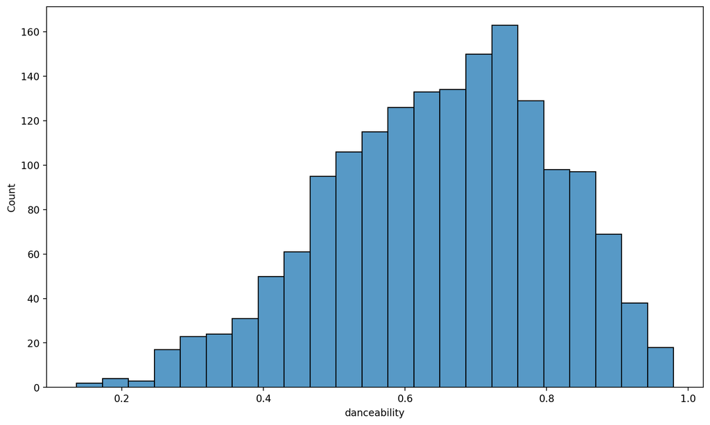

```python
# Visualizing the distribution of the danceability variable
sns.histplot(data = Spotify_DF, x = "danceability")
```

# Exploratory Scatterplots

Choosing some random variables to see if there is any variables with strong predictive power

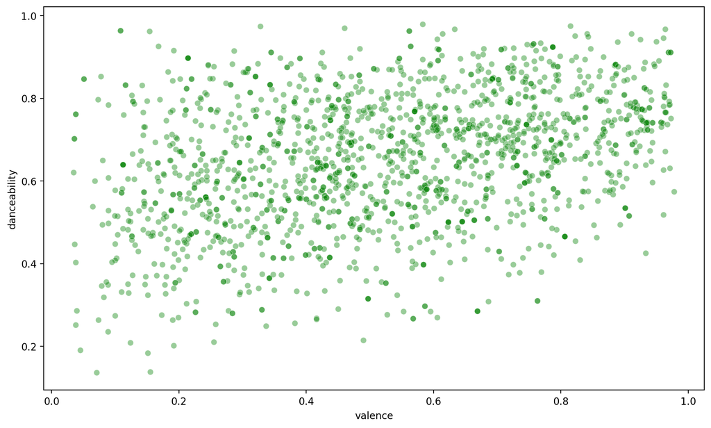

```python
sns.scatterplot(Spotify_DF, x = "valence", y = "danceability", alpha = 0.4, color = 'green')
```

Slight positive slope, but ainly random cloud, suggesting *potential* predictive power

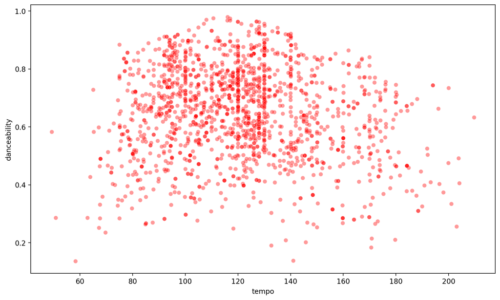

```python
sns.scatterplot(Spotify_DF, x = "tempo", y = "danceability", alpha = 0.4, color = 'red')
```

Surprisingly not much to pull from this, considering tempo is often associated with dancing

Since these and others provided no singular stand out variable, we will let Subset Selection do the work

# Methods Overview

1. Best Subset Selection
2. OLS Regression
3. Decision Tree Regressor
4. GridSearchCV
5. Evaluation

```python
models_best
```

|  | RSS | model |
| --- | --- | --- |
| 1 | 42.655946 | <statsmodels.regression.linear_model.Regressio... |
| 2 | 37.62201 | <statsmodels.regression.linear_model.Regressio... |
| 3 | 35.351401 | <statsmodels.regression.linear_model.Regressio... |
| 4 | 34.274019 | <statsmodels.regression.linear_model.Regressio... |
| 5 | 33.338523 | <statsmodels.regression.linear_model.Regressio... |
| 6 | 32.598684 | <statsmodels.regression.linear_model.Regressio... |
| 7 | 32.093478 | <statsmodels.regression.linear_model.Regressio... |

RSS keeps dropping as we add predictors, leveling off at 7

```python
print(models_best.loc[7, "model"].summary())
```

```
                                 OLS Regression Results
=======================================================================================
Dep. Variable:           danceability   R-squared (uncentered):                   0.957
Model:                            OLS   Adj. R-squared (uncentered):              0.957
Method:                 Least Squares   F-statistic:                              5403.
Date:                Tue, 28 Apr 2026   Prob (F-statistic):                        0.00
Time:                        04:29:01   Log-Likelihood:                          947.18
No. Observations:                1686   AIC:                                     -1880.
Df Residuals:                    1679   BIC:                                     -1842.
Df Model:                           7
Covariance Type:            nonrobust
====================================================================================
                       coef    std err          t      P>|t|      [0.025      0.975]
------------------------------------------------------------------------------------
energy              -0.1938      0.025     -7.705      0.000      -0.243      -0.144
loudness             0.0086      0.001      6.692      0.000       0.006       0.011
valence              0.2429      0.015     15.994      0.000       0.213       0.273
time_signature       0.1078      0.008     13.219      0.000       0.092       0.124
speechiness          0.3524      0.034     10.265      0.000       0.285       0.420
track_popularity     0.0041      0.000     10.429      0.000       0.003       0.005
duration_ms      -2.965e-07   5.77e-08     -5.141      0.000    -4.1e-07   -1.83e-07
==============================================================================
Omnibus:                       31.379   Durbin-Watson:                   1.629
Prob(Omnibus):                  0.000   Jarque-Bera (JB):               32.816
Skew:                          -0.337   Prob(JB):                     7.49e-08
Kurtosis:                       2.891   Cond. No.                     2.27e+06
==============================================================================

Notes:
[1] R² is computed without centering (uncentered) since the model does not contain a constant.
[2] Standard Errors assume that the covariance matrix of the errors is correctly specified.
[3] The condition number is large, 2.27e+06. This might indicate that there are
strong multicollinearity or other numerical problems.
```

# GridSearchCV Tuning

```python
#importing required package
from sklearn.model_selection import GridSearchCV

# our parameter limits for each end to prevent overfitting
param_grid = {
    "tree__max_depth": [3,5,7],
    "tree__min_samples_leaf": [5,10,15]
}

grid_search = GridSearchCV(
    pipeline, param_grid, cv=5, scoring = "r2")
grid_search.fit(X_train,y_train)

print("Best parameters:", grid_search.best_params_)
```

```
Best parameters: {'tree__max_depth': 5, 'tree__min_samples_leaf': 5}
```

Max depth of 5 so the tree doesn't go too deep and overfit

Min leaf samples of 5 so each leaf needs 5 datapoints

# Visualizing the Regression Tree

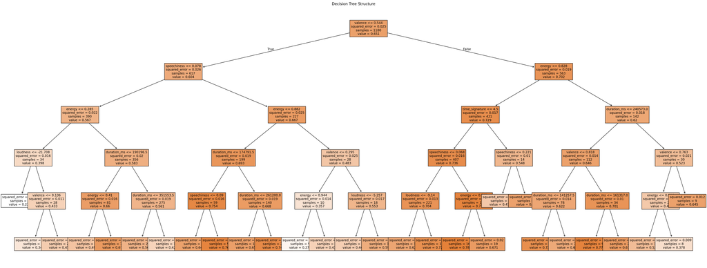

```python
from sklearn.tree import plot_tree

plt.figure(figsize=(40, 15))
plot_tree(
    regressor,
    feature_names = ["energy", "loudness", "valence", "time_signature", "speechiness", "track_popularity", "duration_ms"],
    filled=True,
    fontsize=10
)
plt.title("Decision Tree Structure")
plt.show()
```

- Root split on **valence**, most important variable
- **Speechiness** appearing early as well
- Note the missing leaves, min_samples_leaf doing its job

# Example: Most Danceable Song

By the actual data: [*Ice Ice Baby*](https://youtu.be/rog8ou-ZepE?si=xsvR7yfiTLy-Gzik&t=7) has the highest danceability score of 0.979

# Results Summary

**Valence** strongest predictor, emotional tone matters most

**Speechiness** rap and hip-hop style vocal content is a driver

**Time Signature** regular beat structure aids

**Energy** a negative coefficient suggests that high intensity does not imply highly danceable

# Conclusion

- Dance builds community in a time of disconnect
- Recipe for a danceable song: **positive tone + vocal presence + strong rhythm**
- Artists and producers now have a databacked roadmap

# Reflection

What worked well:

What I struggled with:

1. Pipeline and GridSearchCV syntax
2. Not overfitting the tree
3. Jupyter Notebook Slides!

What I would do differently:

1. Make genre, sub-genre, playlist genre, and other variables numeric ordinal variables to see if they have input
2. Try other models for comparison, maybe Random Forest
3. Explore within each genre to see if the results differe upon closer inspection

# Citations

Corning, Anna. “Disconnected but Hopeful: What a New Survey Reveals about Civic Life in America.” National Civic League, National Civic League, 6 Oct. 2025.

Mohammed, Ahmed. spotify-music-dataset. Version 1 of 1. 2025.

Sawatsky, Melissa. “Shall We Dance? Building Community and Bridging Cultures.” Culturally Modified, 2019.